# RandomForest

### Random Forest with all the variables

• Random forest builds multiple decision trees and merges them together to get a more accurate and stable prediction.

• It builds an ensemble of decision trees, usually trained with the “bagging” method. The general idea of the bagging method is that a combination of learning models increases the overall result.

• Table shows accuracy and kappa for the number of trees given as mtry.

• Printing the top 20 variables (based on their Variable importance) to the table below.

| mtry | Accuracy | Kappa |
| --- | --- | --- |
| 2 | 0.7085883 | 0.0000000 |
| 27 | 0.7383670 | 0.2472408 |
| 53 | 0.7398364 | 0.2699108 |

| Variable | Importance |
| --- | --- |
| Status_checking_accountlt_0 | 100.00000 |
| Duration_in_month | 65.74813 |
| Credit_amount | 55.53972 |
| Credit_historyAll_paid_duly | 40.83071 |
| Jobmanagement | 37.87207 |
| Status_checking_accountlt_200 | 36.98872 |
| Credit_historyNo_credit_due | 36.15392 |
| Savings_account_bondslt_100 | 29.26501 |
| PropertyReal.estate | 28.11664 |
| PurposeFurniture | 22.68152 |
| PurposeNew.car | 21.13056 |
| Credit_historydelayed_in_past | 18.83430 |
| PurposeRepairs | 18.80924 |
| Present_employment_since1_yr | 18.79455 |
| Personal_status_and_sexmale.single | 17.34324 |
| Guarantorsco_applicant | 17.07636 |
| PurposeBusiness | 16.73483 |
| Propertycar | 16.52835 |
| Installment_rate_in_percentage_of_disp_income35_plus | 15.73435 |
| Other_installment_plansbanks | 15.66491 |

• Plot shows variable importance on the x-axis and the variable names on the y-axis

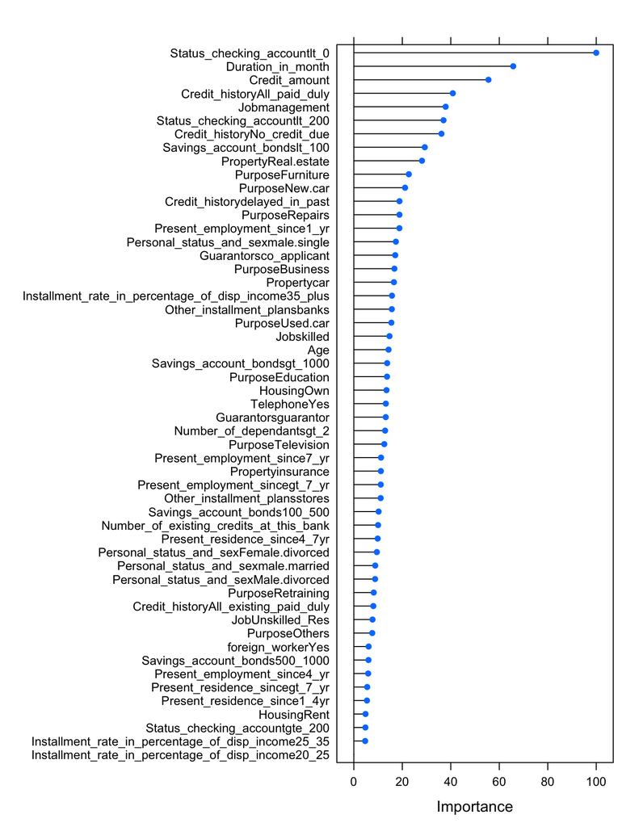

TRAIN FIT

|  | Bad | Good |
| --- | --- | --- |
| Bad | 112 | 9 |
| Good | 92 | 487 |

TRAIN FIT PERFORMANCE

| term | estimate |
| --- | --- |
| accuracy | 0.8557143 |
| kappa | 0.6031033 |
| sensitivity | 0.9818548 |
| specificity | 0.5490196 |
| pos_pred_value | 0.8411054 |
| neg_pred_value | 0.9256198 |
| precision | 0.8411054 |
| recall | 0.9818548 |
| f1 | 0.9060465 |
| prevalence | 0.7085714 |
| detection_rate | 0.6957143 |
| detection_prevalence | 0.8271429 |
| balanced_accuracy | 0.7654372 |

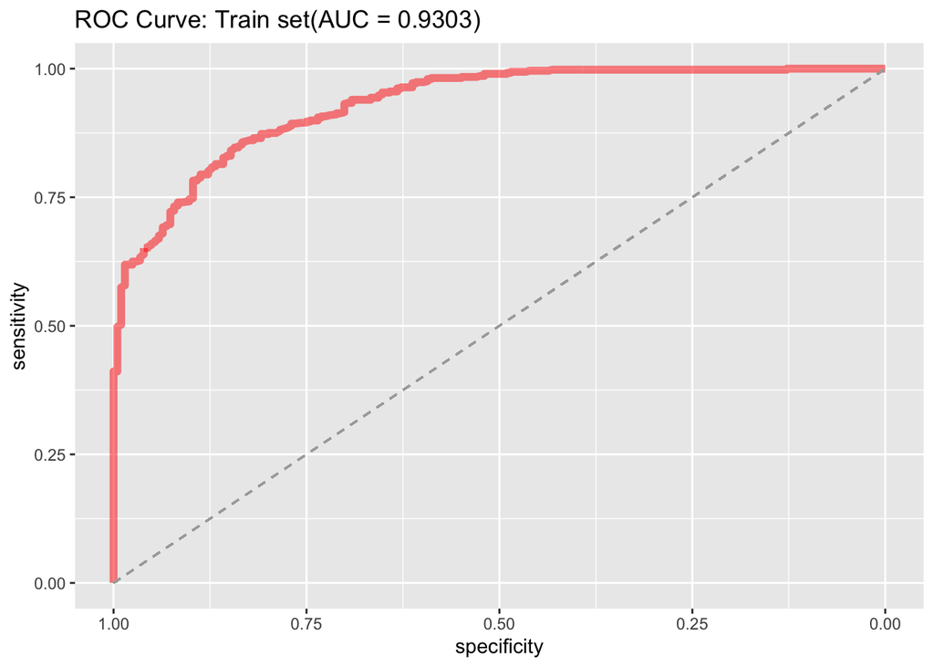

TEST FIT

|  | Bad | Good |
| --- | --- | --- |
| Bad | 34 | 13 |
| Good | 62 | 191 |

TEST FIT PERFORMANCE

| term | estimate |
| --- | --- |
| accuracy | 0.7500000 |
| kappa | 0.3358130 |
| sensitivity | 0.9362745 |
| specificity | 0.3541667 |
| pos_pred_value | 0.7549407 |
| neg_pred_value | 0.7234043 |
| precision | 0.7549407 |
| recall | 0.9362745 |
| f1 | 0.8358862 |
| prevalence | 0.6800000 |
| detection_rate | 0.6366667 |
| detection_prevalence | 0.8433333 |
| balanced_accuracy | 0.6452206 |

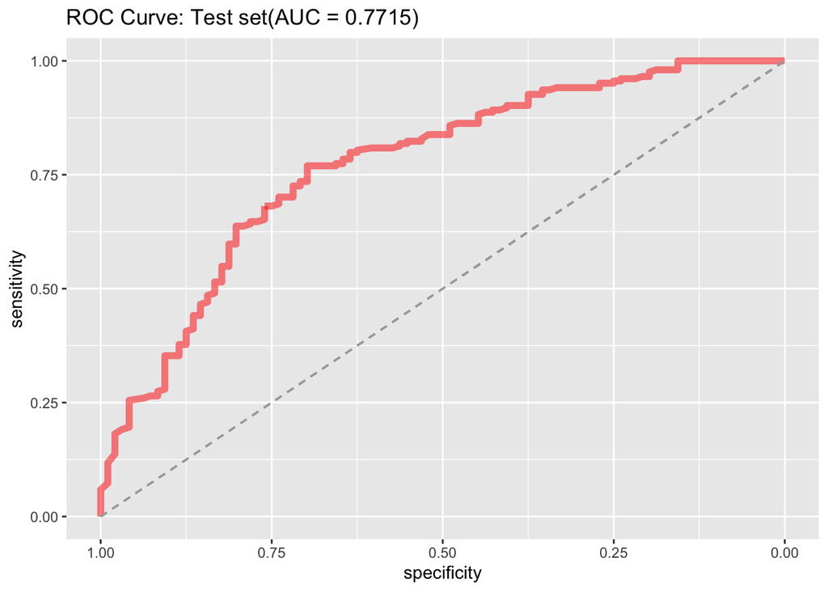

• Below are the significant variables from Random forest model

| Significant Variables |
| --- |
| Age |
| Credit_amount |
| Credit_history |
| Duration_in_month |
| Guarantors |
| Job |
| Personal_status_and_sex |
| Present_employment_since |
| Property |
| Purpose |
| Savings_account_bonds |
| Status_checking_account |
| Present_residence_since |
| Credit_Risk |

### Model with significant variables

• Building Random forest model with Significant variables identified from Variable Importance.

• Let’s look at the train confusion matrix, their accuracies and other model performance measures.

RANDOM FOREST MODEL

| mtry | Accuracy | Kappa |
| --- | --- | --- |
| 2 | 0.6900223 | 0.0422149 |
| 22 | 0.7397280 | 0.3205717 |
| 42 | 0.7325433 | 0.3131030 |

TRAIN FIT

|  | Bad | Good |
| --- | --- | --- |
| Bad | 134 | 16 |
| Good | 89 | 461 |

TRAIN FIT PERFORMANCE

| term | estimate |
| --- | --- |
| accuracy | 0.8500000 |
| kappa | 0.6215242 |
| sensitivity | 0.9664570 |
| specificity | 0.6008969 |
| pos_pred_value | 0.8381818 |
| neg_pred_value | 0.8933333 |
| precision | 0.8381818 |
| recall | 0.9664570 |
| f1 | 0.8977605 |
| prevalence | 0.6814286 |
| detection_rate | 0.6585714 |
| detection_prevalence | 0.7857143 |
| balanced_accuracy | 0.7836769 |

TEST FIT

|  | Bad | Good |
| --- | --- | --- |
| Bad | 27 | 20 |
| Good | 50 | 203 |

TEST FIT PERFORMANCE

| term | estimate |
| --- | --- |
| accuracy | 0.7666667 |
| kappa | 0.2991122 |
| sensitivity | 0.9103139 |
| specificity | 0.3506494 |
| pos_pred_value | 0.8023715 |
| neg_pred_value | 0.5744681 |
| precision | 0.8023715 |
| recall | 0.9103139 |
| f1 | 0.8529412 |
| prevalence | 0.7433333 |
| detection_rate | 0.6766667 |
| detection_prevalence | 0.8433333 |
| balanced_accuracy | 0.6304816 |